# ECom_Data-Analysis

- **Hackthon Team Name : "Code Commandos"**
- **Team Members :**
1. **Naisha Raval**
2. **Yashvardhan Jani**
3. **Ayushi Sapariya**
4. **Krishn Pachani**
5. **Prince Valand**

```python
# import important libraries

import pandas as pd
import numpy as np
import matplotlib.pyplot as plt
%matplotlib inline
import seaborn as sns
import warnings
warnings.simplefilter(action="ignore")
```

```python
df = pd.read_csv("Flipkart_Mobiles_Data.csv") # add .csv file of Data-set
```

```python
df.head() # show first 5 rows of Data-set
```

|  | Brand | Model | Color | Memory | Storage | Rating | Selling Price | Original Price |
| --- | --- | --- | --- | --- | --- | --- | --- | --- |
| 0 | OPPO | A53 | Moonlight Black | 4 GB | 64 GB | 4.5 | 11990 | 15990 |
| 1 | OPPO | A53 | Mint Cream | 4 GB | 64 GB | 4.5 | 11990 | 15990 |
| 2 | OPPO | A53 | Moonlight Black | 6 GB | 128 GB | 4.3 | 13990 | 17990 |
| 3 | OPPO | A53 | Mint Cream | 6 GB | 128 GB | 4.3 | 13990 | 17990 |
| 4 | OPPO | A53 | Electric Black | 4 GB | 64 GB | 4.5 | 11990 | 15990 |

# **Data Cleaning**

```python
df.isnull().sum() # check null values
```

|  | 0 |
| --- | --- |
| Brand | 0 |
| Model | 0 |
| Color | 0 |
| Memory | 43 |
| Storage | 39 |
| Rating | 144 |
| Selling Price | 0 |
| Original Price | 0 |

**dtype:** int64

# **Replacing NULL Ratings with Average Rating**

```python
df["Rating"].replace(np.nan,df["Rating"].mean(),inplace=True)
```

```python
df.isnull().sum() # check null values
```

|  | 0 |
| --- | --- |
| Brand | 0 |
| Model | 0 |
| Color | 0 |
| Memory | 43 |
| Storage | 39 |
| Rating | 0 |
| Selling Price | 0 |
| Original Price | 0 |

**dtype:** int64

```python
df.shape # Before dropping NULL values (rows,columns)
```

```
(3114, 8)
```

# **Dropping Rows which have NULL Memory and Storage**

```python
df.dropna(subset=["Memory","Storage"],inplace=True)
```

```python
df.shape # After dropping NULL values (rows,columns)
```

```
(3032, 8)
```

```python
df.isnull().sum() # Checking NULL Values
```

|  | 0 |
| --- | --- |
| Brand | 0 |
| Model | 0 |
| Color | 0 |
| Memory | 0 |
| Storage | 0 |
| Rating | 0 |
| Selling Price | 0 |
| Original Price | 0 |

**dtype:** int64

# **Description of whole Data :**

```python
df.describe()
```

|  | Rating | Selling Price | Original Price |
| --- | --- | --- | --- |
| count | 3032.000000 | 3032.000000 | 3032.000000 |
| mean | 4.241398 | 26186.404354 | 28113.184697 |
| std | 0.266696 | 29291.841572 | 30843.861948 |
| min | 2.300000 | 1000.000000 | 1000.000000 |
| 25% | 4.100000 | 9996.000000 | 10490.000000 |
| 50% | 4.300000 | 15299.500000 | 16990.000000 |
| 75% | 4.400000 | 28999.000000 | 31489.250000 |
| max | 5.000000 | 179900.000000 | 189999.000000 |

```python
df.info()
```

```
<class 'pandas.core.frame.DataFrame'>
Index: 3032 entries, 0 to 3113
Data columns (total 8 columns):
 #   Column          Non-Null Count  Dtype
---  ------          --------------  -----
 0   Brand           3032 non-null   object
 1   Model           3032 non-null   object
 2   Color           3032 non-null   object
 3   Memory          3032 non-null   object
 4   Storage         3032 non-null   object
 5   Rating          3032 non-null   float64
 6   Selling Price   3032 non-null   int64
 7   Original Price  3032 non-null   int64
dtypes: float64(1), int64(2), object(5)
memory usage: 213.2+ KB
```

# **Analysing Brands**

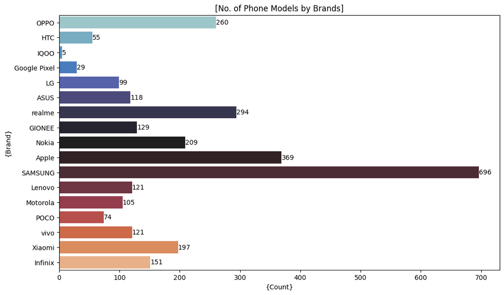

```python
plt.figure(figsize=(12, 7))
ax = sns.countplot(y="Brand",data=df,palette="icefire")
for bars in ax.containers:
    ax.bar_label(bars)
plt.title("[No. of Phone Models by Brands]")
plt.xlabel("{Count}")
plt.ylabel("{Brand}")
plt.show()
```

- **Samsung have the most number of mobile phones followed by Apple and realme.**

# **Analysing Most Costly Brands**

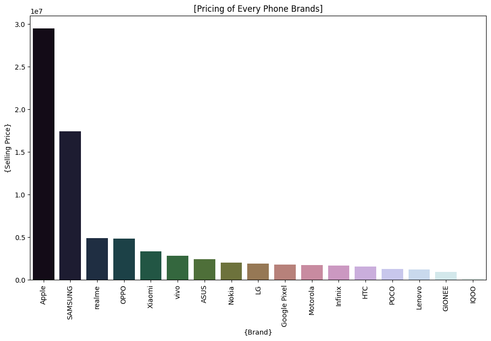

```python
most_costly_brand = df.groupby(["Brand"],as_index=False)["Selling Price"].sum().sort_values(by="Selling Price",ascending=False)
plt.figure(figsize=(12, 7))
sns.barplot(x="Brand",y="Selling Price",data=most_costly_brand,palette="cubehelix")
plt.xticks(rotation=90)
plt.title("[Pricing of Every Phone Brands]")
plt.xlabel("{Brand}")
plt.ylabel("{Selling Price}")
plt.show()
```

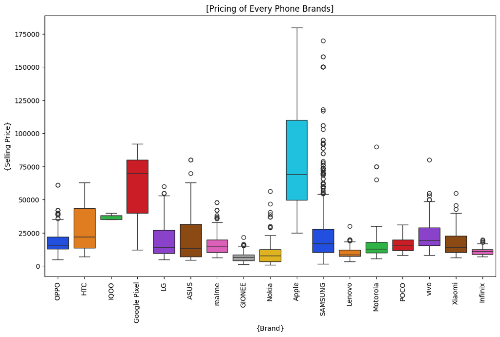

```python
plt.subplots(figsize=(12, 7))
sns.boxplot(x="Brand",y="Selling Price",data=df,palette="bright")
plt.xticks(rotation=90)
plt.title("[Pricing of Every Phone Brands]")
plt.xlabel("{Brand}")
plt.ylabel("{Selling Price}")
plt.show()
```

- **Apple is the most costly selling brand followed by Samsung.**

# **Range Wise Analysis (Low Range(0-15000), Mid Range(16000-40000), Premium Range(above 40000) Smartphones)**

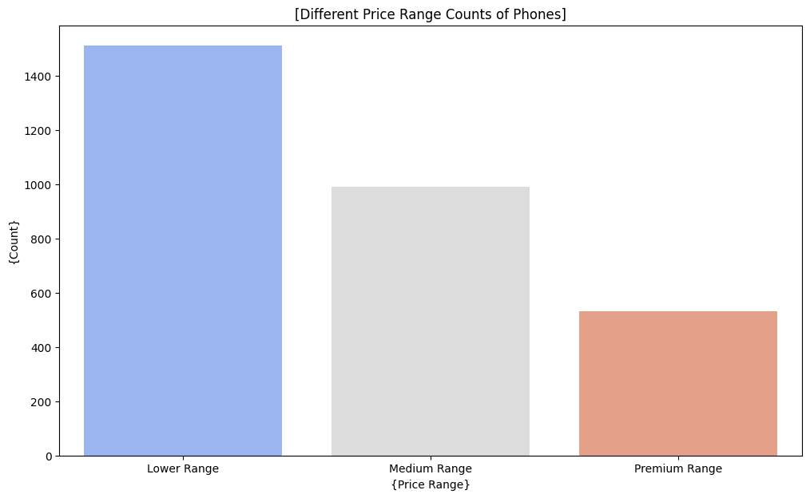

```python
df["Price Range"] = pd.cut(df["Selling Price"], bins=[0, 15000, 40000, float("inf")], labels=["Lower Range", "Medium Range", "Premium Range"])
plt.figure(figsize=(12, 7))
sns.countplot(x="Price Range",data=df,palette="coolwarm")
plt.title("[Different Price Range Counts of Phones]")
plt.xlabel("{Price Range}")
plt.ylabel("{Count}")
plt.show()
```

- **Most of the Smartphones belong to Lower Range Category(0-15000 Rs).**

# **Average Selling Price of Each Brand**

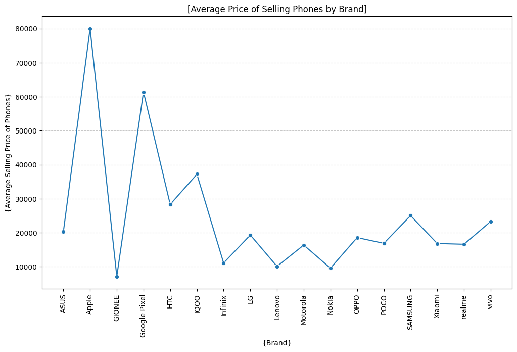

```python
avg_sp_bybrand = df.groupby(["Brand"], as_index=False)["Selling Price"].mean()
plt.figure(figsize=(12, 7))
sns.lineplot(x="Brand", y="Selling Price", data=avg_sp_bybrand, marker="o")
plt.xticks(rotation=90)
plt.xlabel("{Brand}")
plt.ylabel("{Average Selling Price of Phones}")
plt.title("[Average Price of Selling Phones by Brand]")
plt.grid(axis='y', linestyle='--', alpha=0.7)
plt.show()
```

- **Apple Brand has the Highest Average Selling Price among all, followed by Google Pixel.**

# **Most Costly Selling Model in Each Brand**

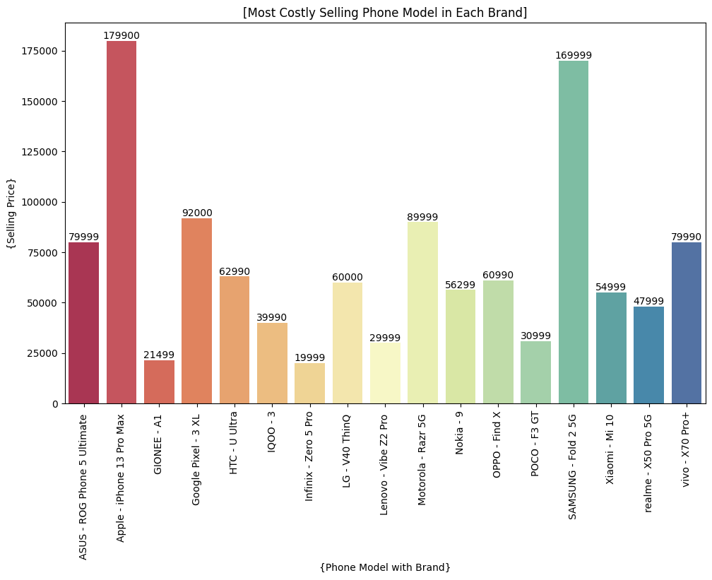

```python
plt.figure(figsize=(11.7, 7))
most_costly_model = df.loc[df.groupby("Brand")["Selling Price"].idxmax()]
most_costly_model["Brand_Model"] = most_costly_model["Brand"] + " - " + most_costly_model["Model"]
ax = sns.barplot(x="Brand_Model", y="Selling Price", data=most_costly_model, palette="Spectral")
plt.xticks(rotation=90)
for i, j in enumerate(most_costly_model["Selling Price"]):
    ax.text(i, j, str(j), ha="center", va="bottom", fontsize=10)
plt.xlabel("{Phone Model with Brand}")
plt.ylabel("{Selling Price}")
plt.title("[Most Costly Selling Phone Model in Each Brand]")
plt.show()
```

# **Most Common Colors offered by Brands**

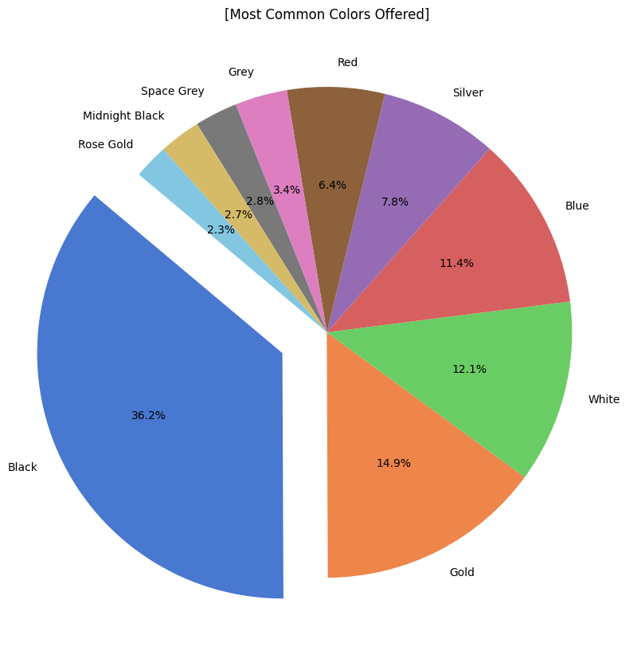

```python
common_colors = df["Color"].value_counts().head(10)
common_colors
plt.figure(figsize=(10,10))
plt.pie(common_colors,labels=common_colors.index,autopct='%1.1f%%',startangle=140,colors=sns.color_palette("muted"),explode=[0.2,0,0,0,0,0,0,0,0,0])
plt.title("[Most Common Colors Offered]")
plt.show()
```

- **Most Common Color offered is Black followed by Gold, White, Blue in decreasing order.**

# **All Unique Colors provided for Phones.**

```python
unique_colors = df["Color"].unique()
print("No. of Unique Colors for Phone Models:")
print(len(unique_colors))
print("\nUnique Colors for Phone Models:")
print(unique_colors)
```

```
No. of Unique Colors for Phone Models:
637

Unique Colors for Phone Models:
['Moonlight Black' 'Mint Cream' 'Electric Black' 'Deep Blue' 'Black'
 'Blue' 'Flowing Silver' 'Crystal Blue' 'Ink Black' 'Lake Green'
 'Mystery Black' 'Fantastic Purple' 'Matte Black' 'Moonlight Gold'
 'Aurora' 'Stellar Black' 'Magic Blue' 'Starry Blue' 'Crystal Black'
 'Metallic White' 'Fantasy White' 'Navy Blue' 'Fancy Blue' 'Pearl Blue'
 'Astral Blue' 'CRYSTAL BLACK' 'Dynamic Black' 'Dynamic Orange'
 'Mystery Blue' 'Fairy White' 'Fluid Black' 'Sky White' 'Midnight Black'
 'Rainbow Silver' 'Auroral Blue' 'Crystal Silver' 'Space Silver'
 'Fancy White' 'Midnight Blue' 'Glaring Gold' 'Starry Black' 'Red'
 'JET BLACK' 'Luminous Black' 'Unicorn White' 'Prism Black' 'Piano Black'
 'Classic Silver' 'Lightening Black' 'Marine Green' 'Bordeaux Red'
 'Galactic Blue' 'Marble Green' 'Diamond Blue' 'Silky White'
 'Starry Night' 'Space Purple' 'Dazzling White' 'Rose Gold' 'Gold'
 'Blazing Blue' 'Purple' 'Champagne' 'Aurora Blue' 'Mist Black'
 'Twilight Black' 'Stream White' 'Vanilla Mint' 'Green' 'Grey'
 'Sunrise Red' 'Twilight Blue' 'Starry Purple' 'Glowing Gold'
 'Glowing Black' 'Diamond Red' 'Glaze Blue' 'Mirror Black' 'Jade Black'
 'White' 'Stellar Purple' 'Fluorite Purple' 'Waterfall Grey'
 'Aurora Green' 'Thunder Black' 'Fancy white' 'Jewelry White' 'Silver'
 'Glacier Blue' 'Neon Purple' 'Space Blue' 'Jet Black' 'Majestic Gold'
 'Ocean Green' 'Ocean Blue' 'Starry purple' 'Amazing Silver' 'Blue MB'
 'Quantum Silver' 'Tornado Black' ' Tornado Black' 'Just Black'
 'Clearly White' 'Not Pink' 'Very Silver' 'Aurora Silver' 'midnight blue'
 'Midnight Purple' 'Moroccan Blue' 'Smokey Gray' 'Black Blue' 'MAGIC BLUE'
 'Thunder Blue' 'Thunder blue' 'Platinum' 'Titan' 'Silver Titan'
 'Platinum Grey' 'Brown' 'Ice' 'Black Titan' 'AURORA SILVER' 'Aurora Gray'
 'Laser Blue' 'Black & Blue' 'Black Gold' 'Gold & Black' 'Illusion Sky'
 'Carbon' 'Genuine Leather Black' 'Titan Silver' 'Pink' 'Metallic Gray'
 'Lavender Violet' 'Genuine Leather Brown' 'Meteor Silver' 'Silver Blue'
 'Yellow' 'Rose Pink' 'Titanium' 'Aqua Blue' 'Orange' 'Cool Blue'
 'Cool Grey' 'Racing Blue' 'Racing Silver' 'Cross Black' 'Cross Blue'
 'Space Black' 'Watery Grey' 'Watery Blue' 'Universe Blue' 'Metal Grey'
 'Universe Purple' 'Laser Black' 'Supersonic Black' 'Supersonic Blue'
 'Infinite Black' 'Power Blue' 'Infinite Blue' 'Cyber Silver'
 'Cyber Black' 'Power Silver' 'Rich Grey' 'Rich Green' 'Mist Blue'
 'Nebula' 'Sword Black' 'Blade Silver' 'Frozen Blue' 'Chroma White'
```

[output cut: 89 more lines]

```
 'Celestial Magic' 'Stealth Black' 'Purple Mist' 'Pacific Pearl'
 'Camo Green' 'Aquamarine Blue' 'Stardust White' 'Diamond Dazzle'
 'Aegean Blue' 'Purple  ' 'Morandi Green' 'Polar Black' 'Green Wave'
 'Silver Wave' 'Emerald Green' 'Quetzal Cyan' 'Ocean Wave'
 'Celestial Snow' 'Symphony Cyan' 'Haze Green' 'Glacier Green'
 'Mithril Grey' 'Nordic Secret' 'Milan Black' 'Sandstone Black' 'Ice Blue'
 'Sapphire Cyan' 'Bordeaux Red ' 'Heart of Ocean' 'Silver Diamond'
 'Topaz Blue' 'Moonlight Jade' 'Amber Red' 'Aether Black' 'Tradew Grey'
 'Mocha Brown' 'City Blue' 'Serene Gold' 'Blush Gold' 'Magic Gold'
 'Shark Grey' 'Quartz Black' 'Charcoal Blue' 'Black Diamond' 'Berlin Gray'
 'Twilight Purple' 'Bolivia Blue' 'Bronze Gold Black' 'Startrails Blue'
 'Shadow Grey' 'Rainbow Fantasy' 'Starlight Black' 'Royal Gold'
 'Storm White' 'Alpine Green' 'Glowing Galaxy' 'Meteor Black'
 'Stargaze White' 'Sunrise Blue ' 'Azure Glow' 'Starry Glow'
 'Glowing Green' 'Blazing Black' 'Icy Blue']
```

- **Total No. of Unique Colors for Phone Models : 637**

# **Rating-wise Analysis of Brands**

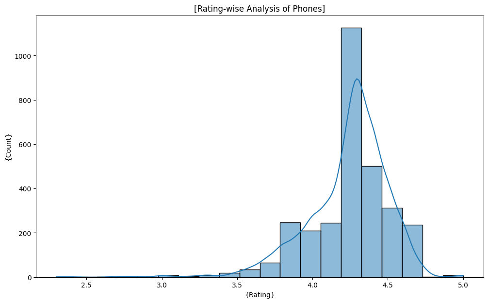

```python
plt.figure(figsize=(11.9, 7))
sns.histplot(df['Rating'], bins=20, kde=True)
plt.xlabel("{Rating}")
plt.ylabel("{Count}")
plt.title("[Rating-wise Analysis of Phones]")
plt.show()
```

- **Mean Rating is 4.24 STAR.**

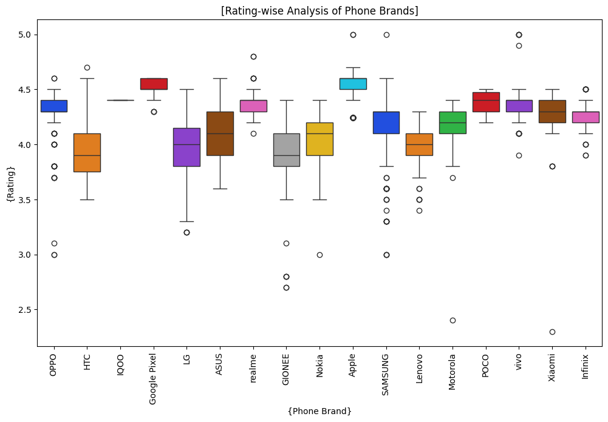

```python
plt.subplots(figsize=(12,7))
sns.boxplot(x="Brand",y="Rating",data=df,palette="bright")
plt.xticks(rotation=90)
plt.xlabel("{Phone Brand}")
plt.ylabel("{Rating}")
plt.title("[Rating-wise Analysis of Phone Brands]")
plt.show()
```

- **Apple is the most Rated brand followed by Google Pixel.**

# **Analysis by RAM offered by Brands**

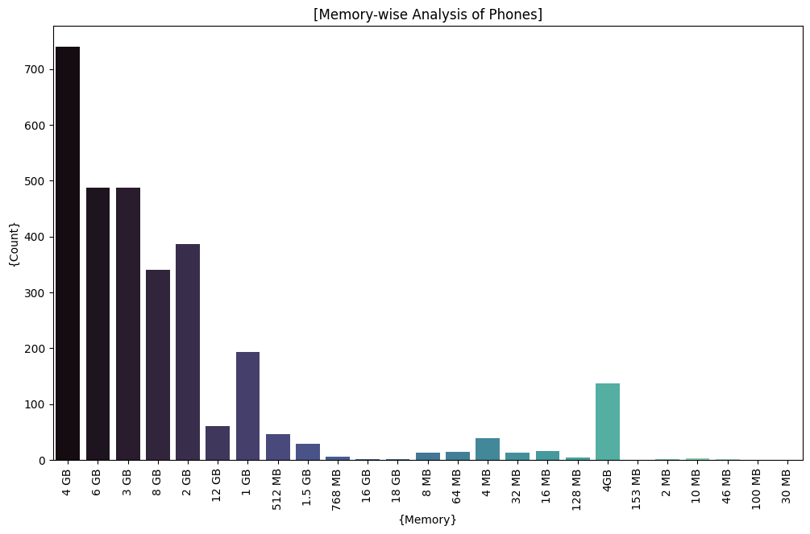

```python
plt.figure(figsize=(12,7))
sns.countplot(x="Memory",data=df,palette="mako")
plt.xticks(rotation=90)
plt.xlabel("{Memory}")
plt.ylabel("{Count}")
plt.title("[Memory-wise Analysis of Phones]")
plt.show()
```

- **Most of the Phones which are available with 4GB RAM.**

# **Analysis by Storage offered by Brands**

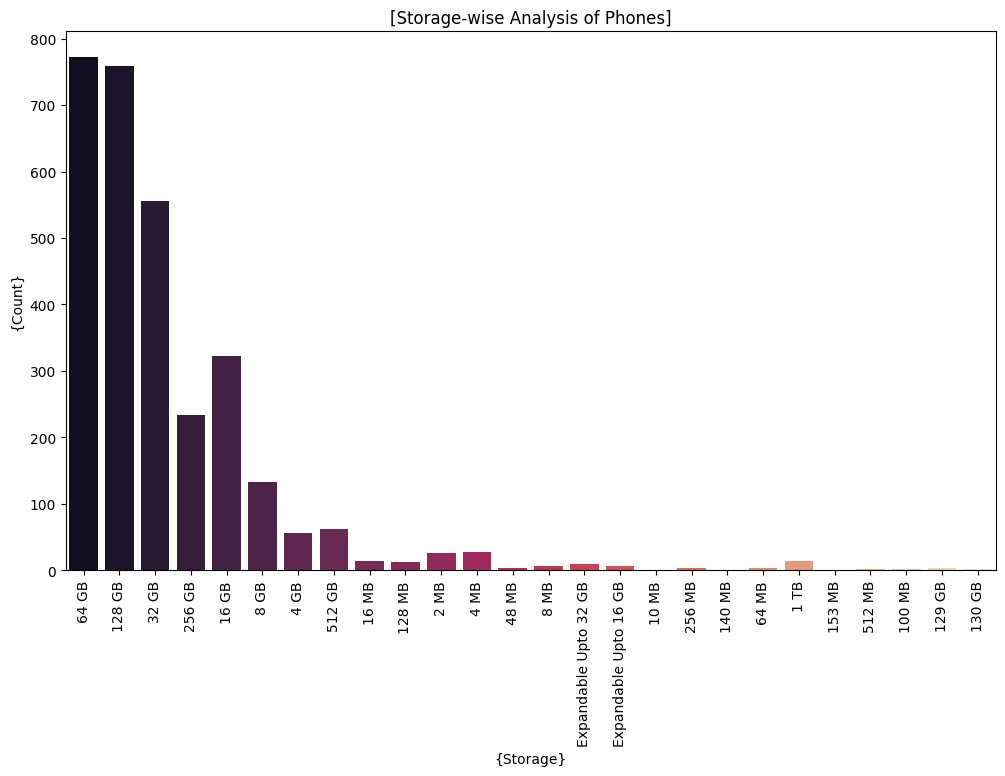

```python
plt.figure(figsize=(12,7))
sns.countplot(x="Storage",data=df,palette="rocket")
plt.xticks(rotation=90)
plt.xlabel("{Storage}")
plt.ylabel("{Count}")
plt.title("[Storage-wise Analysis of Phones]")
plt.show()
```

- **Most of the Phones which are available with 64GB Storage.**

# **Top 10 Rated Phone Models**

```python
top10_models = df.nlargest(10,"Rating")
top10_models
```

|  | Brand | Model | Color | Memory | Storage | Rating | Selling Price | Original Price | Price Range |
| --- | --- | --- | --- | --- | --- | --- | --- | --- | --- |
| 1252 | Apple | iPhone 7 Plus | Red | 3 GB | 256 GB | 5.0 | 85400 | 85400 | Premium Range |
| 1348 | Apple | iPhone 7 Plus | Red | 3 GB | 256 GB | 5.0 | 85400 | 85400 | Premium Range |
| 2021 | SAMSUNG | SM-B310EZDDINS | Black | 100 MB | 100 MB | 5.0 | 1949 | 1949 | Lower Range |
| 2789 | vivo | X60 Pro | Shimmer Blue | 12 GB | 256 GB | 5.0 | 48780 | 48780 | Premium Range |
| 2791 | vivo | X50 | Frost Blue | 8 GB | 256 GB | 5.0 | 44990 | 44990 | Premium Range |
| 2797 | vivo | Z1x | Phantom Purple | 6 GB | 64 GB | 5.0 | 19990 | 19990 | Medium Range |
| 2799 | vivo | S2 | Diamond Black | 4 GB | 128 GB | 5.0 | 19990 | 19990 | Medium Range |
| 2771 | vivo | Y33T | Mirror Black | 8 GB | 128 GB | 4.9 | 22990 | 22990 | Medium Range |
| 3061 | realme | 9 5G | Meteor Black | 6 GB | 128 GB | 4.8 | 17499 | 20999 | Medium Range |
| 3062 | realme | 9 5G | Stargaze White | 6 GB | 128 GB | 4.8 | 17499 | 20999 | Medium Range |

# **Most Discounted Model**

```python
df['Discount Percentage'] = ((df['Original Price'] - df['Selling Price']) / df['Original Price']) * 100
df[df['Discount Percentage']==df['Discount Percentage'].max()]
```

|  | Brand | Model | Color | Memory | Storage | Rating | Selling Price | Original Price | Price Range | Discount Percentage |
| --- | --- | --- | --- | --- | --- | --- | --- | --- | --- | --- |
| 803 | GIONEE | Pioneer P3 | White | 512 MB | 4 GB | 3.6 | 2350 | 7996 | Lower Range | 70.610305 |

- **GIONEE Brand is offering a 70.61 percent discount on Model Pioneer P3 which is the highest discount percentage among all models.**

# **Rating v/s Selling Price**

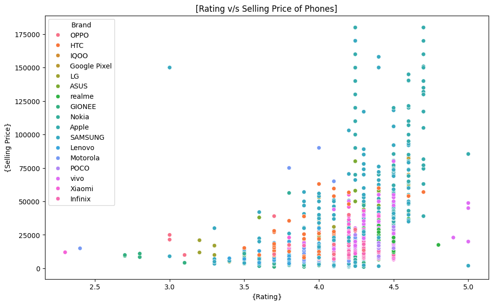

```python
plt.figure(figsize=(11.7,7))
sns.scatterplot(x='Rating', y='Selling Price', data=df,hue="Brand")
plt.xlabel("{Rating}")
plt.ylabel("{Selling Price}")
plt.title("[Rating v/s Selling Price of Phones]")
plt.show()
```

- **Number of Selling Phones is Highest between 4.0-4.5 STAR with Selling Price under 50,000 Rs.**

# **Correlation Matrix**

```python
corr_matrix = df.corr(numeric_only=True)
corr_matrix
```

|  | Rating | Selling Price | Original Price | Discount Percentage |
| --- | --- | --- | --- | --- |
| Rating | 1.000000 | 0.404179 | 0.403896 | 0.053857 |
| Selling Price | 0.404179 | 1.000000 | 0.985189 | -0.060141 |
| Original Price | 0.403896 | 0.985189 | 1.000000 | 0.059051 |
| Discount Percentage | 0.053857 | -0.060141 | 0.059051 | 1.000000 |

# **HeatMap**

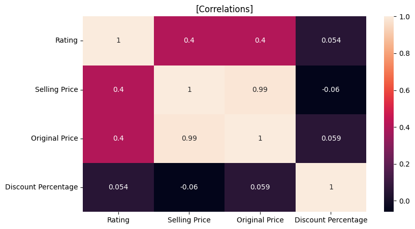

```python
plt.figure(figsize=(9, 5))
sns.heatmap(corr_matrix, annot=True)
plt.title("[Correlations]")
plt.show()
```

- **Correlation between Rating, Selling Price, Original Price & Discount Percentage**

# **Conclusion :-**

- **The availability of Lower Price Range Phones Should be Increased as most buyers buy phones in 15000 range.**
- **Mean Rating is 4.24 STAR.**
- **It is not True that only higher selling price products have a higher rating maximum mobiles lying between 0 to 25000 also have a Good Rating.**
- **Vivo is providing more rated products and those are value for money also.**
- **Apple is the most costly selling brand followed by Samsung.**
- **Apple is the most Rated brand followed by Google Pixel.**
- **Apple Brand has the Highest Average Selling Price among all, followed by Google Pixel and then followed by IQOO.**
- **Samsung have the most number of mobile phones followed by Apple and realme.**
- **GIONEE Brand is offering a 70.61% discount on Model "Pioneer P3" which is the highest discount percentage among all models.**
- **Most of the Phones which are available with 4 GB RAM & 64 GB Storage.**
- **Most Common Color offered is Black & Total number of Unique Colors for Phone Models are 637.**